# Project

Daniel Walker

4/30/2019

```r
# always clean up R environment
rm (list = ls ())

#install.packages('RCurl')

# load all packages here
library (mdsr)
library (dplyr) # for data manipluation
library (ggplot2) # data visualization
library (reshape2) # reshaping

# user-defined functions here (if any)

# load data
```

### Clean and Load Data

Reads in data, turns drink name into ascii to remove tradmark value in drink data set. The beverage name, Bevarge size, and how the beverage was made, was then transformed into digits and letters using regualr expressions

```r
# read data https://www.kaggle.com/starbucks/starbucks-menu
drinks_expanded <- read.csv('starbucks_drinkMenu_expanded.csv')
food <- read.csv('starbucks-menu-nutrition-food.csv')

# as the data seems to contains some trademarks and accent, we will first remove them
drinks_expanded$Beverage_category <- iconv (drinks_expanded$Beverage_category, "latin1", "ASCII", sub = "byte")
drinks_expanded$Beverage <- iconv (drinks_expanded$Beverage, "latin1", "ASCII", sub = "byte")
drinks_expanded$Beverage_prep <- iconv (drinks_expanded$Beverage_prep, "latin1", "ASCII", sub = "byte")

drinks_expanded$Beverage_category <- gsub ('(<[a-z0-9]+>)','',drinks_expanded$Beverage_category)
drinks_expanded$Beverage <- gsub ('(<[a-z0-9]+>)','',drinks_expanded$Beverage)
drinks_expanded$Beverage_prep <- gsub ('(<[a-z0-9]+>)','',drinks_expanded$Beverage_prep)
```

### Quick view of Data

First six instances in each dataset

```r
head (food)
```

```
##                                Food.name Calories Fat Carb Fiver Protein
## 1                           Chonga Bagel      300   5   50     3      12
## 2                           8-Grain Roll      380   6   70     7      10
## 3                       Almond Croissant      410  22   45     3      10
## 4                          Apple Fritter      460  23   56     2       7
## 5                       Banana Nut Bread      420  22   52     2       6
## 6 Blueberry Muffin with Yogurt and Honey      380  16   53     1       6
```

```r
head (drinks_expanded)
```

```
##         Beverage_category      Beverage     Beverage_prep Calories
## 1                  Coffee Brewed Coffee             Short        3
## 2                  Coffee Brewed Coffee              Tall        4
## 3                  Coffee Brewed Coffee            Grande        5
## 4                  Coffee Brewed Coffee             Venti        5
## 5 Classic Espresso Drinks    Caff Latte Short Nonfat Milk       70
## 6 Classic Espresso Drinks    Caff Latte           2% Milk      100
##   Total_Fat Trans_Fat Saturated_Fat Sodium Total_Carbohydrates Cholesterol
## 1       0.1       0.0           0.0      0                   5           0
## 2       0.1       0.0           0.0      0                  10           0
## 3       0.1       0.0           0.0      0                  10           0
## 4       0.1       0.0           0.0      0                  10           0
## 5       0.1       0.1           0.0      5                  75          10
## 6       3.5       2.0           0.1     15                  85          10
##   Dietary_Fibre Sugars Protein Vitamin_A Vitamin_C Calcium Iron Caffeine
## 1             0      0     0.3       0.0         0    0.00    0      175
## 2             0      0     0.5       0.0         0    0.00    0      260
## 3             0      0     1.0       0.0         0    0.00    0      330
## 4             0      0     1.0       0.0         0    0.02    0      410
## 5             0      9     6.0       0.1         0    0.20    0       75
## 6             0      9     6.0       0.1         0    0.20    0       75
```

### Plot Strar Bucks Food (Calories and Fat)

Graph of fat versus calories of a starbucks food item, blue line daily recomendation of fat by Universisty of Colorado Colorado Springs, citation below, red line in graph is recomendation of calories citation below

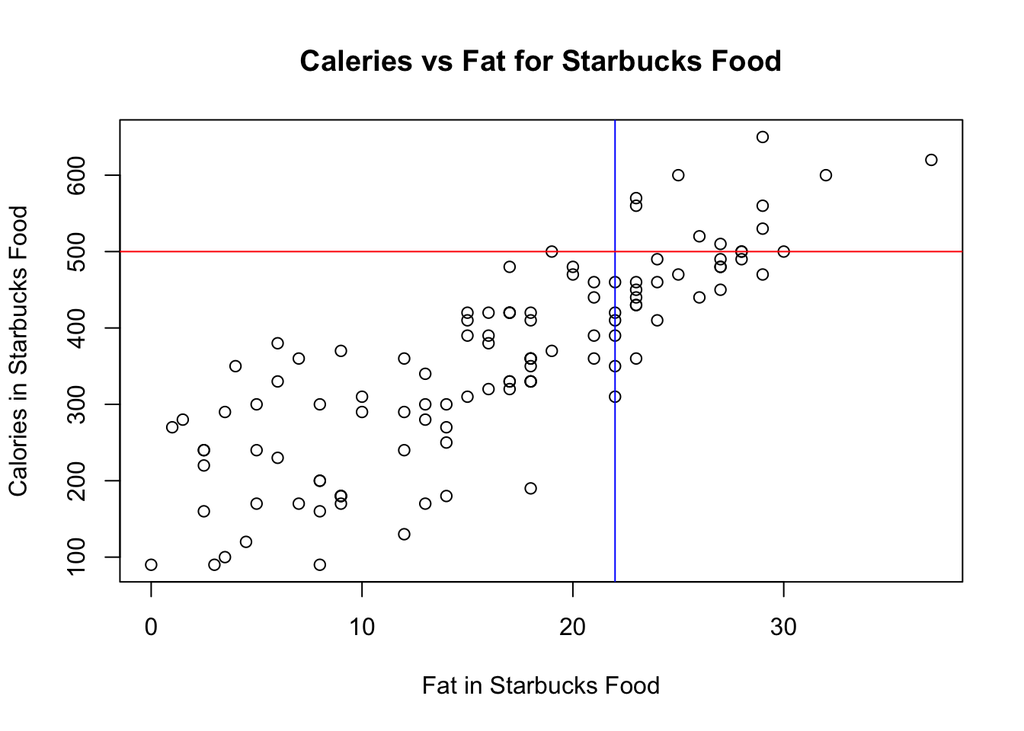

```r
# red line shows recomended meal amount of Calories for food
# blue line shows MAX recomended daily amount of Fat for Food

# https://www.uccs.edu/healthcircle/sites/healthcircle/files/inline-files/Meal%20Planning.pdf
# https://my.clevelandclinic.org/health/articles/11208-fat-what-you-need-to-know

plot (Calories~Fat,
     ylab = 'Calories in Starbucks Food',
     xlab = 'Fat in Starbucks Food',
     main = 'Caleries vs Fat for Starbucks Food',
     data = food)
abline (v=22, col='blue')
abline (h=500, col='red')
```

```r
food %>%
  select (Food.name,Calories,Fat) %>%
  filter (Calories>=500,Fat>=22) %>%
  count (Food.name) %>%
  ungroup () %>%
  arrange (desc (n))
```

```
## # A tibble: 13 x 2
##    Food.name                                                 n
##    <fct>                                                 <int>
##  1 Chicken Artichoke on Ancient Grain Flatbread              1
##  2 Green Goddess Avocado Salad                               1
##  3 Lentils & Vegetable Protein Bowl with Brown Rice          1
##  4 PB&J Protein Box                                          1
##  5 Roasted Turkey & Dill Havarti Sandwich                    1
##  6 Sausage Cheddar & Egg Breakfast Sandwich                  1
##  7 Seared Steak & Cheddar Sandwich                           1
##  8 Smoked Mozzarella & Roasted Pepper Sandwich               1
##  9 Spicy Chorizo  Monterey Jack & Egg Breakfast Sandwich     1
## 10 Strawberries & Jam Sandwich                               1
## 11 Turkey & Fire-Roasted Corn Salad                          1
## 12 Turkey Pesto Panini                                       1
## 13 Za'atar Chicken & Lemon Tahini Salad                      1
```

```r
# Unhealthiest Option
food %>%
  select (Food.name, Calories, Fat) %>%
  filter (Calories>=600, Fat>=28) %>%
  count (Food.name) %>%
  ungroup () %>%
  arrange (desc (n))
```

```
## # A tibble: 3 x 2
##   Food.name                                            n
##   <fct>                                            <int>
## 1 Green Goddess Avocado Salad                          1
## 2 Lentils & Vegetable Protein Bowl with Brown Rice     1
## 3 Roasted Turkey & Dill Havarti Sandwich               1
```

```r
if (FALSE){
"
Green Goddess Avocado Salad
Lentils & Vegetable Protein Bowl with Brown Rice
Roasted Turkey & Dill Havarti Sandwich
"
}
```

### Plot Starbucks Drink (Calories and Total Fat)

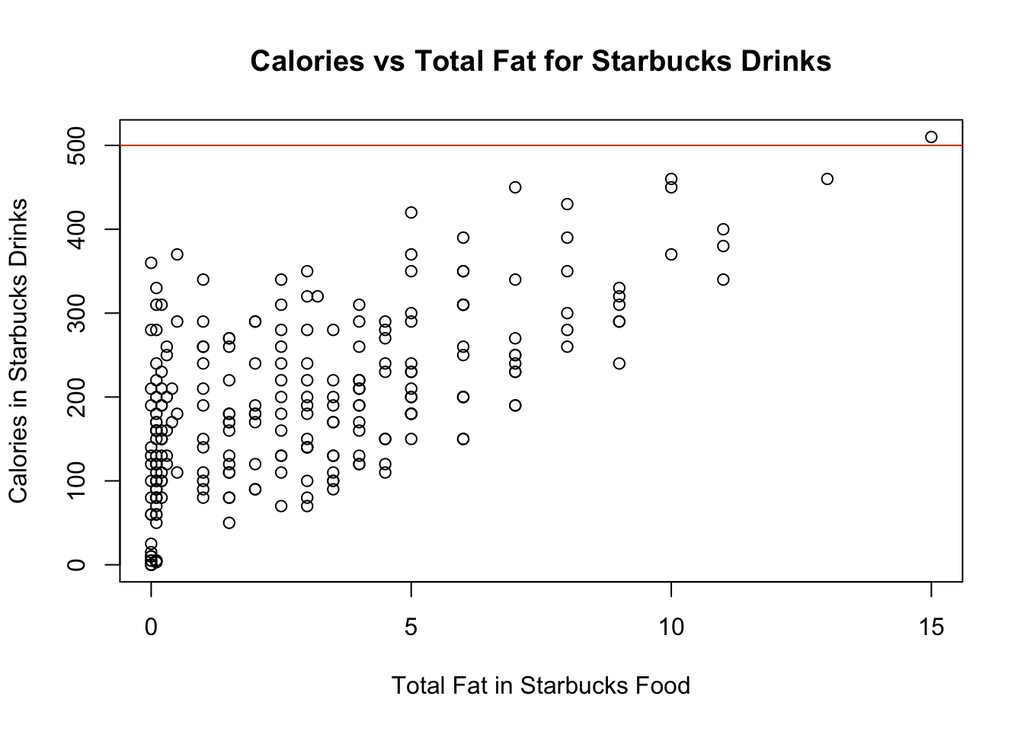

```r
# red line shows recomended meal amount of Calories for food

# https://www.uccs.edu/healthcircle/sites/healthcircle/files/inline-files/Meal%20Planning.pdf
# https://my.clevelandclinic.org/health/articles/11208-fat-what-you-need-to-know

plot (Calories~Total_Fat,
     ylab = 'Calories in Starbucks Drinks',
     xlab = 'Total Fat in Starbucks Food',
     main = 'Calories vs Total Fat for Starbucks Drinks',
     data = drinks_expanded)
abline (h = 500, col = 'red')
```

### Plot Strar Bucks Drink (Sugars and Total Fat)

Graph of Fat and Sugar Content in Starbucks drinks red line in graph is max standard set by University of California Sanfrancisco for daily amount of sugar Citation below

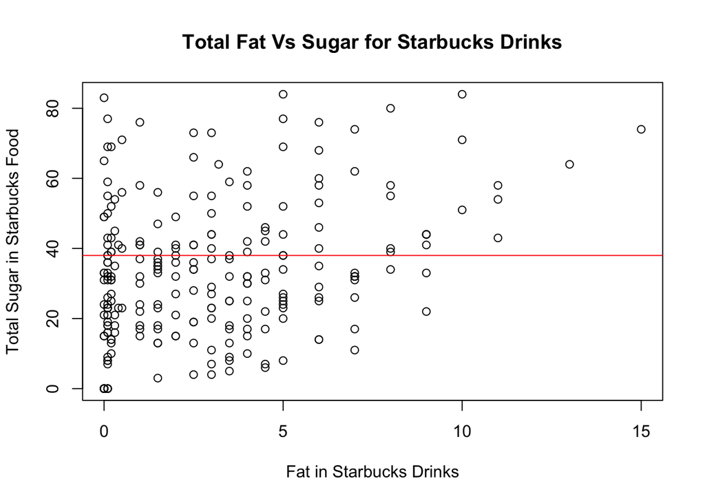

```r
# red line shows MAX recomended meal amount of sugar for food

# http://sugarscience.ucsf.edu/the-growing-concern-of-overconsumption.html

plot (Sugars ~ Total_Fat,
     xlab = 'Fat in Starbucks Drinks',
     ylab = 'Total Sugar in Starbucks Food',
     main = 'Total Fat Vs Sugar for Starbucks Drinks',
     data = drinks_expanded)
abline (h = 38, col = 'red')
```

### Plot Strar Bucks Drink (Sugars and Caffine)

Clean Caffeine variable in Starbucks Drink variable, creates scatter plot of Caffine and sugar, red line shows the Federal Goverments standard for Caffine intake, Citation below, Finds Drinks whith highest sugar content, and expected value for number of drinks that violate standards set by University of California San Francisco, Citation above

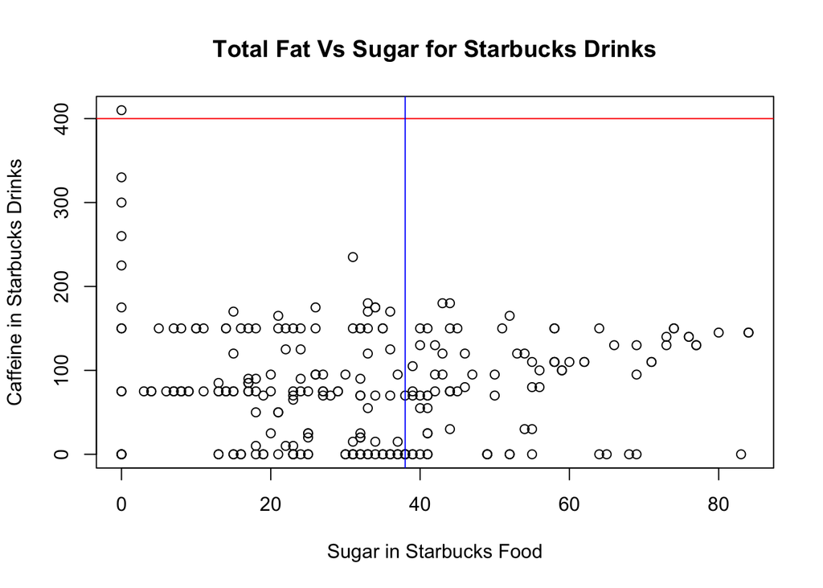

```r
# Blue line Max recomendation of sugar
# Red line Max recomendation of caffine

# https://www.fda.gov/consumers/consumer-updates/spilling-beans-how-much-caffeine-too-much

sudo <- drinks_expanded %>%
  mutate (clean_caff = as.numeric (as.character (drinks_expanded$Caffeine)))
sudo[is.na (sudo)] <- 0

plot (clean_caff~Sugars,
     ylab = 'Caffeine in Starbucks Drinks',
     xlab = 'Sugar in Starbucks Food',
     main = 'Total Fat Vs Sugar for Starbucks Drinks',
     data = sudo)
abline (h=400, col='red')
abline (v=38, col='blue')
```

```r
# Venti Coffee
sudo %>%
  select (Beverage_category, clean_caff) %>%
  filter (clean_caff >= 400)
```

```
##   Beverage_category clean_caff
## 1            Coffee        410
```

```r
sudo %>%
  select (Beverage_category, Sugars) %>%
  filter (Sugars >= 38) %>%
  count (Beverage_category) %>%
  ungroup () %>%
  arrange (desc (n))
```

```
## # A tibble: 8 x 2
##   Beverage_category                    n
##   <chr>                            <int>
## 1 Frappuccino Blended Coffee          33
## 2 Signature Espresso Drinks           19
## 3 Tazo Tea Drinks                     17
## 4 Frappuccino Blended Crme            10
## 5 Classic Espresso Drinks              4
## 6 Frappuccino Light Blended Coffee     4
## 7 Smoothies                            3
## 8 Shaken Iced Beverages                1
```

```r
sudo_sugar <- sudo %>%
  select (Beverage_category, Sugars) %>%
  filter (Sugars >= 38)

# 37.60331% of drinks have higher than rated sugar
length (sudo_sugar[,1]) / length (drinks_expanded$Beverage_category)
```

```
## [1] 0.3760331
```

```r
if (FALSE){
"
Worst drinks ordered by violation of sugar contents
Frappuccino Blended Coffee
Signature Espresso Drinks
Tazo Tea Drinks
"
}
```

#### Checking for missing values

It doesnt seems the data contains any missing values. However, Caffeine variable in the `Drinks Expanded` dataset seems to be a mixed of numeric and character. As it can be seen, there are values with value `varies` or `Varies` in the data. Removed them from the dataset and will format it into numeric variable.

```
##  Beverage_category    Beverage         Beverage_prep         Calories
##  Length:242         Length:242         Length:242         Min.   :  0.0
##  Class :character   Class :character   Class :character   1st Qu.:120.0
##  Mode  :character   Mode  :character   Mode  :character   Median :185.0
##                                                           Mean   :193.9
##                                                           3rd Qu.:260.0
##                                                           Max.   :510.0
##
##    Total_Fat        Trans_Fat     Saturated_Fat        Sodium
##  Min.   : 0.000   Min.   :0.000   Min.   :0.0000   Min.   : 0.000
##  1st Qu.: 0.200   1st Qu.:0.100   1st Qu.:0.0000   1st Qu.: 0.000
##  Median : 2.500   Median :0.500   Median :0.0000   Median : 5.000
##  Mean   : 2.905   Mean   :1.307   Mean   :0.0376   Mean   : 6.364
##  3rd Qu.: 4.500   3rd Qu.:2.000   3rd Qu.:0.1000   3rd Qu.:10.000
##  Max.   :15.000   Max.   :9.000   Max.   :0.3000   Max.   :40.000
##
##  Total_Carbohydrates  Cholesterol    Dietary_Fibre        Sugars
##  Min.   :  0.0       Min.   : 0.00   Min.   :0.0000   Min.   : 0.00
##  1st Qu.: 70.0       1st Qu.:21.00   1st Qu.:0.0000   1st Qu.:18.00
##  Median :125.0       Median :34.00   Median :0.0000   Median :32.00
##  Mean   :128.9       Mean   :35.99   Mean   :0.8058   Mean   :32.96
##  3rd Qu.:170.0       3rd Qu.:50.75   3rd Qu.:1.0000   3rd Qu.:43.75
##  Max.   :340.0       Max.   :90.00   Max.   :8.0000   Max.   :84.00
##
##     Protein         Vitamin_A         Vitamin_C          Calcium
##  Min.   : 0.000   Min.   :0.00000   Min.   :0.00000   Min.   :0.0000
##  1st Qu.: 3.000   1st Qu.:0.04000   1st Qu.:0.00000   1st Qu.:0.1000
##  Median : 6.000   Median :0.08000   Median :0.00000   Median :0.2000
##  Mean   : 6.979   Mean   :0.09831   Mean   :0.03649   Mean   :0.2076
##  3rd Qu.:10.000   3rd Qu.:0.15000   3rd Qu.:0.00000   3rd Qu.:0.3000
##  Max.   :20.000   Max.   :0.50000   Max.   :1.00000   Max.   :0.6000
##
##       Iron            Caffeine
##  Min.   :0.00000   75     :37
##  1st Qu.:0.00000   0      :35
##  Median :0.02000   150    :34
##  Mean   :0.07446   70     :14
##  3rd Qu.:0.10000   varies :12
##  Max.   :0.50000   95     :11
##                    (Other):99
```

```
##                                 Food.name      Calories
##  8-Grain Roll                        :  1   Min.   : 90.0
##  Almond Croissant                    :  1   1st Qu.:280.0
##  Ancho Chipotle Chicken Panini       :  1   Median :360.0
##  Apple Fritter                       :  1   Mean   :356.6
##  Bacon Gouda & Egg Breakfast Sandwich:  1   3rd Qu.:450.0
##  Banana Nut Bread                    :  1   Max.   :650.0
##  (Other)                             :107
##       Fat             Carb           Fiver          Protein
##  Min.   : 0.00   Min.   : 5.00   Min.   : 0.00   Min.   : 1.00
##  1st Qu.: 9.00   1st Qu.:31.00   1st Qu.: 1.00   1st Qu.: 5.00
##  Median :17.00   Median :42.00   Median : 2.00   Median : 8.00
##  Mean   :16.35   Mean   :41.49   Mean   : 2.85   Mean   :11.47
##  3rd Qu.:23.00   3rd Qu.:53.00   3rd Qu.: 3.00   3rd Qu.:19.00
##  Max.   :37.00   Max.   :80.00   Max.   :21.00   Max.   :34.00
##
```

#### Distribution of the variables in each of the datasets

Drinks expanded dataset, shown by histogram of each feature

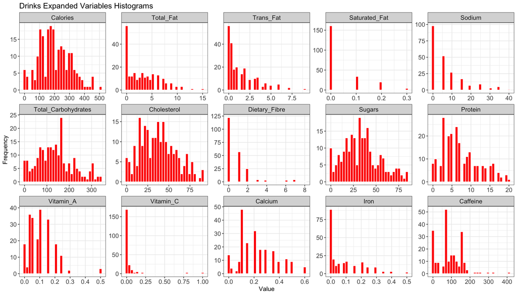

### Food dataset

Histogram of each feature in the Starbucks Food data set

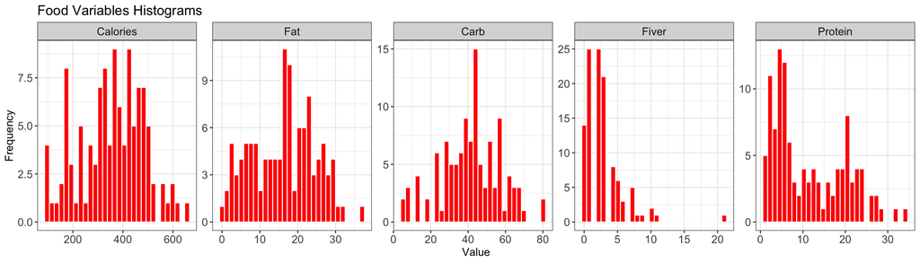

### Supervised learning

Fit linear model to predict number of Calories in a drink based on other variables such as Total_Fat, Trans_Fat. Sugars etc. 5 folds cross validation Used and will use `MAPE` (mean average error percentage) as the perforamce metrics. Once we have the `MAPE` for each fold, I will simply take the average of all folds and this will be the final `MAPE`

```r
# randomly shuffle the data, set seed to produce the same resultss
# in addition, remove the first 3 columns which contains the Beverage descriptions
set.seed (380)
drinks_expanded <- drinks_expanded[sample(nrow(drinks_expanded)),] %>%
  select (-contains("Beverage"))

# create 5 equally size folds
K <- 5
folds <- cut (seq (1, nrow (drinks_expanded)), breaks = K, labels = FALSE)

# Perform 5 folds cross validation
MAPE <- c ()
for (i in 1:K){
    index <- which (folds==i, arr.ind=TRUE)
    train <- drinks_expanded[-index, ]
    test <- drinks_expanded[index, ]
    model <- lm (Calories ~., data=train)
    prediction <- predict (model,test)
    MAPE[i] <- abs (test$Calories / prediction - 1)
}

paste0 ('MAPE for 5 folds: ', round (mean (MAPE)*100, 2),'%')
```

```
## [1] "MAPE for 5 folds: 5.89%"
```

### Unspurviesd learning

for the unspurviesd part, I will use the food dataset. We will use “Hierarchical Clustering” in order to find clusters of similiar foods based on `Calories`, `Fat`, `Carb`, `Fiver` and `Protein`

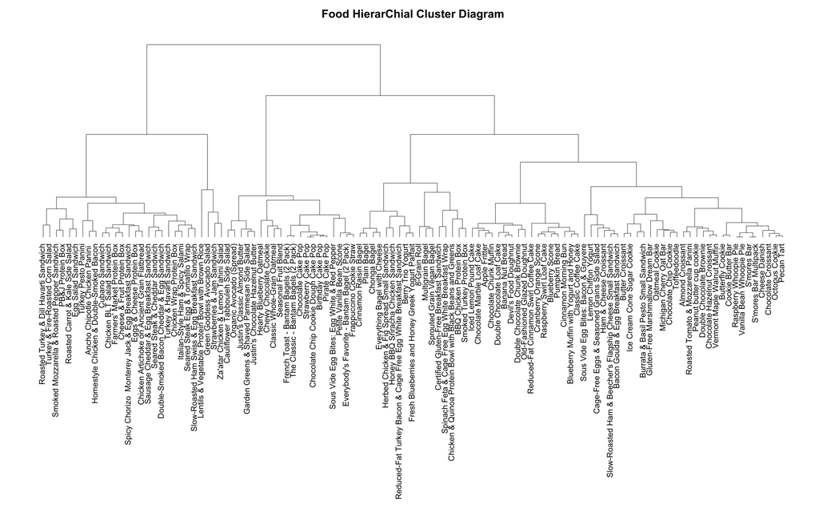

```r
# remove the food column
df <- food %>%
  select (-Food.name)
# set food column as the row names
rownames (df) <- food$Food.name

# scale the data and create distance metrics using euclidean distance.
dd <- dist (scale (df), method = "euclidean")

# fit hierarchical clustering using "ward.D2" method
hc <- hclust (dd, method = "ward.D2")

# plot the results
par (cex = 1, mar = c (2, 2, 4, 1))
plot (hc,
     hang = -1,
     cex = 1.4,
     xlab = "",
     sub = "",
     axes = FALSE,
     ylab = '',
     main = 'Food HierarChial Cluster Diagram',
     cex.main = 2)
```

### Simulation

```r
# https://www.accessdata.fda.gov/scripts/interactivenutritionfactslabel/carbohydrate.html

set.seed (380)
starbucks_order <- function (food_size = 1, drink_size = 1){
  food_samp <- sample (food ,food_size, replace=TRUE)
  drink_samp <- sample (drinks_expanded, drink_size, replace=TRUE)

  total_sugar <- sum (drink_samp$Sugars)
  total_caffine <- sum (drink_samp$Caffeine)
  total_calories <- sum (food_samp$Calories) + sum (drink_samp$Calories)
  total_fat <- sum (food_samp$Fat) + sum (drink_samp$Total_Fat)
  total_carbo <- sum (food_samp$Carb) + sum (drink_samp$Total_Carbohydrates)

  # index 1 sugar
  # index 2 calories
  # index 3 fat
  # index 4 carbo
  # index 5 caffine
  return (c (total_sugar, total_calories, total_fat, total_carbo, total_caffine))
}

food_orders <- 3
drink_orders <- 3
n <- 365
final_sim <- do (n) * starbucks_order (food_orders,drink_orders)
head (final_sim)
```

```
##    V1   V2   V3  V4  V5
## 1  95 1720 56.5 251 165
## 2  84 1390 44.5 320 470
## 3 117 2010 87.0 527 200
## 4  42 1480 53.7 446 225
## 5 137 1780 63.5 625 380
## 6  82 1190 33.0 419 220
```

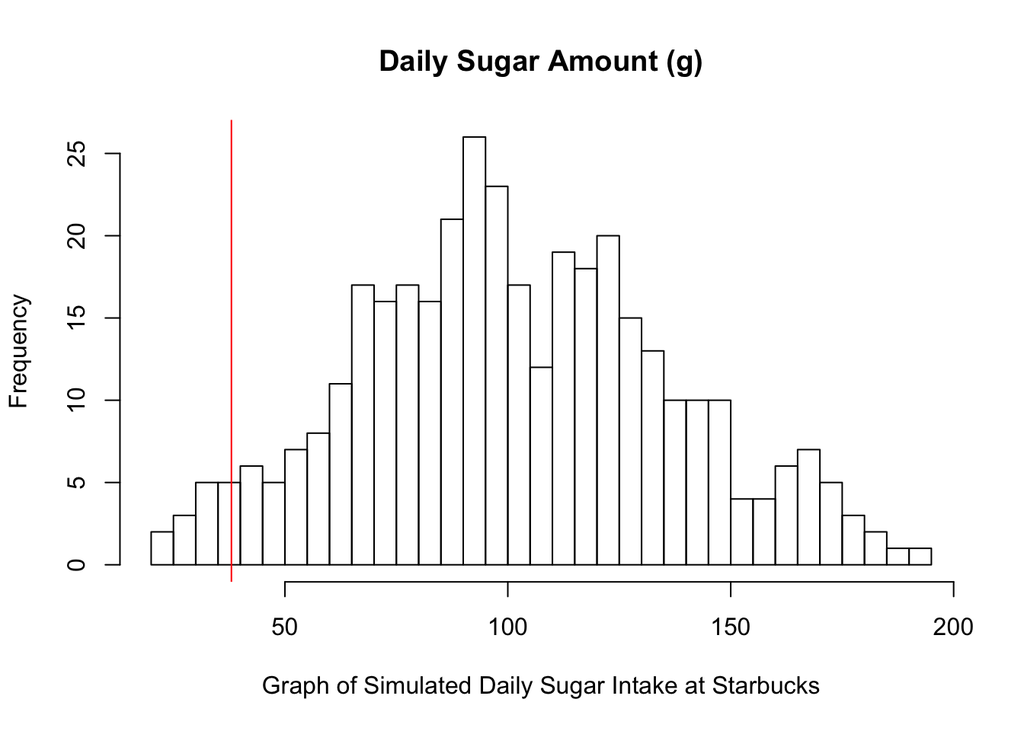

```r
hist (final_sim[,1],
     breaks = 30,
     xlab = 'Graph of Simulated Daily Sugar Intake at Starbucks',
     main = 'Daily Sugar Amount (g)')
abline (v = 38, col = 'red')
```

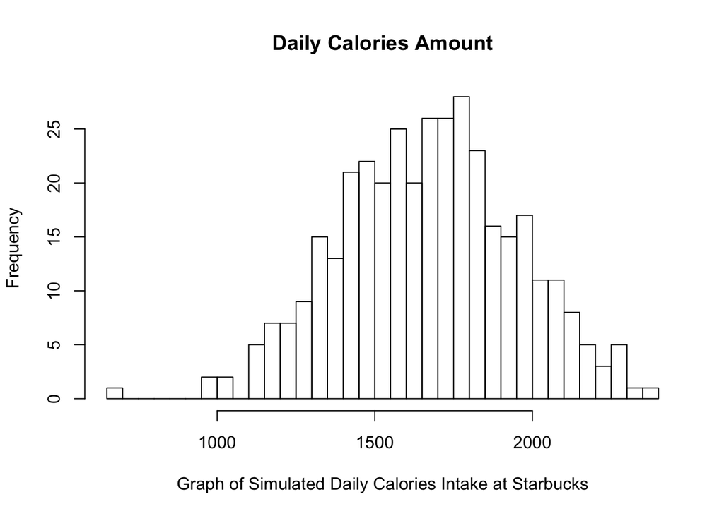

```r
hist (final_sim[,2],
     breaks = 30,
     xlab = 'Graph of Simulated Daily Calories Intake at Starbucks',
     main = 'Daily Calories Amount')
```

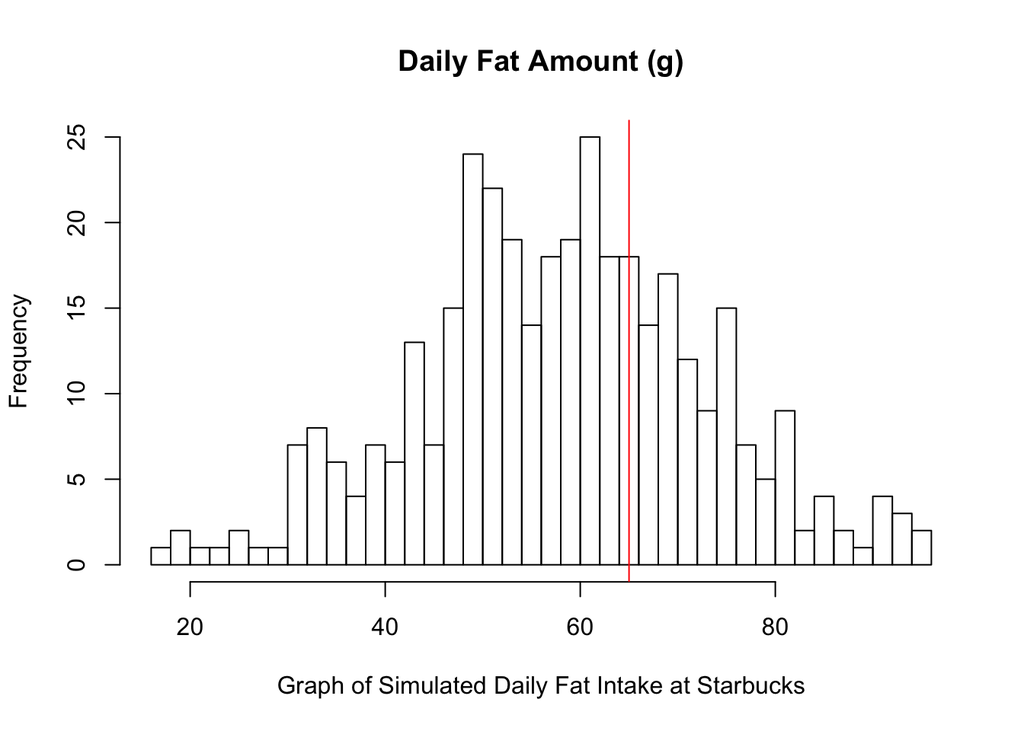

```r
hist (final_sim[,3],
     breaks = 30,
     xlab = 'Graph of Simulated Daily Fat Intake at Starbucks',
     main = 'Daily Fat Amount (g)')
abline (v = 65, col = 'red')
```

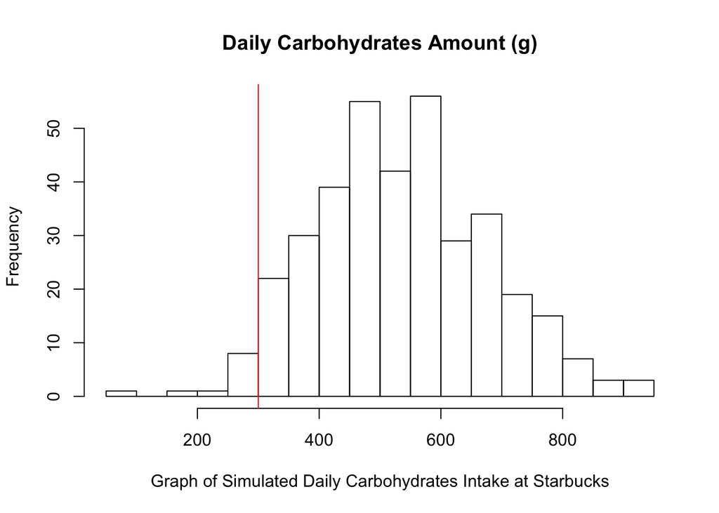

```r
hist (final_sim[,4],
     breaks = 30,
     xlab = 'Graph of Simulated Daily Carbohydrates Intake at Starbucks',
     main = 'Daily Carbohydrates Amount (g)')
abline (v=300,col='red')
```

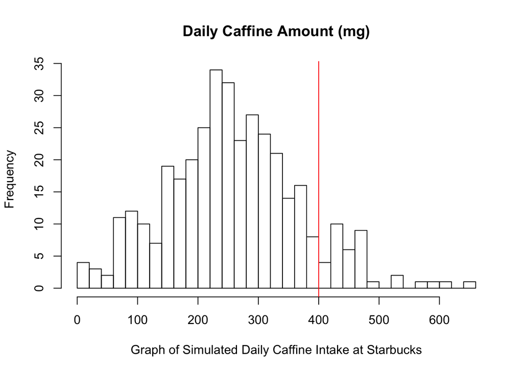

```r
hist (final_sim[,5],
     breaks = 30,
     xlab = 'Graph of Simulated Daily Caffine Intake at Starbucks',
     main = 'Daily Caffine Amount (mg)')
abline (v=400, col='red')
```

```r
cat('Sugar\n')
```

```
## Sugar
```

```r
mean(final_sim[,1])
```

```
## [1] 102.137
```

```r
cat('Calories\n')
```

```
## Calories
```

```r
mean(final_sim[,2])
```

```
## [1] 1674.868
```

```r
cat('Fat\n')
```

```
## Fat
```

```r
mean(final_sim[,3])
```

```
## [1] 58.16055
```

```r
cat('Carbohydrates\n')
```

```
## Carbohydrates
```

```r
mean(final_sim[,4])
```

```
## [1] 536.9808
```

```r
cat('Caffine\n')
```

```
## Caffine
```

```r
mean(final_sim[,5])
```

```
## [1] 259.6027
```